# Test a Perceptual Phenomenon

January 3 2018

John Ngo

# Background

In a Stroop task, participants are presented with a list of words, with each word displayed in a color of ink. The participant’s task is to say out loud the color of the ink in which the word is printed. The task has two conditions: a congruent words condition, and an incongruent words condition. In the congruent words condition, the words being displayed are color words whose names match the colors in which they are printed: for example RED, BLUE. In the incongruent words condition, the words displayed are color words whose names do not match the colors in which they are printed: for example PURPLE, ORANGE. In each case, we measure the time it takes to name the ink colors in equally-sized lists. Each participant will go through and record a time from each condition.

# Questions For Investigation

As a general note, be sure to keep a record of any resources that you use or refer to in the creation of your project. You will need to report your sources as part of the project submission.

What is our independent variable? What is our dependent variable?

What is an appropriate set of hypotheses for this task? What kind of statistical test do you expect to perform? Justify your choices.

Report some descriptive statistics regarding this dataset. Include at least one measure of central tendency and at least one measure of variability.

Provide one or two visualizations that show the distribution of the sample data. Write one or two sentences noting what you observe about the plot or plots.

Now, perform the statistical test and report your results. What is your confidence level and your critical statistic value? Do you reject the null hypothesis or fail to reject it? Come to a conclusion in terms of the experiment task. Did the results match up with your expectations?

Optional: What do you think is responsible for the effects observed? Can you think of an alternative or similar task that would result in a similar effect? Some research about the problem will be helpful for thinking about these two questions!

```python
# import the libraries

import numpy as np
import pandas as pd
import matplotlib.pyplot as plt
import scipy.stats as stats
%matplotlib inline
plt.rc('figure', figsize=(12, 6))


data = pd.read_csv('stroopdata.csv')
```

```python
# list the data

data[['Congruent', 'Incongruent']].head(n=10)
```

|  | Congruent | Incongruent |
| --- | --- | --- |
| 0 | 12.079 | 19.278 |
| 1 | 16.791 | 18.741 |
| 2 | 9.564 | 21.214 |
| 3 | 8.630 | 15.687 |
| 4 | 14.669 | 22.803 |
| 5 | 12.238 | 20.878 |
| 6 | 14.692 | 24.572 |
| 7 | 8.987 | 17.394 |
| 8 | 9.401 | 20.762 |
| 9 | 14.480 | 26.282 |

# 1. What is our independent variable? What is our dependent variable?

Independent variable: Congruent/incongruent words condition

Dependent variable: The time taken for congruent or incongruent conditions

# 2. What is an appropriate set of hypotheses for this task? What kind of statistical test do you expect to perform? Justify your choices.

H0 - Null Hypothesis: (μcongruent = μincongruent). The population average response time in viewing the congruent(c) words and viewing the incongruent(i) words are equal.

Ha - Alternative Hypothesis: (μcongruent ≠ μincongruent). The population mean of Incongruent Test will take longer than congruent test.

According to this statistical test, the sample size was below 30 and we don't know the population's standard deviation of this statistical test. So, a dependent t-Test is the most appropriate statistical test to assume the data was random sampled and normal distributed.

# 3. Report some descriptive statistics regarding this dataset. Include at least one measure of central tendency and at least one measure of variability.

```python
import math

# Congruent Statistics

meanC = np.mean(data['Congruent']); round(meanC,2)
stdC = np.std(data['Congruent'])
medianC = np.median(data['Congruent'])
rangeC = data['Congruent'].max() - data['Congruent'].min()
varC = np.var(data['Congruent'])


# Incongruent Statistics

meanI = np.mean(data['Incongruent']); round(meanI,2)
stdI = np.std(data['Incongruent'])
medianI = np.median(data['Incongruent'])
rangeI = data['Incongruent'].max() - data['Incongruent'].min()
varI = np.var(data['Incongruent'])


print('Congruent (Mean): ' + str(round(meanC,4)))
# print('Congruent (Standard Deviation): ' + str(round(stdC,4)))
print('Congruent (Median): ' + str(round(medianC,4)))
print('Congruent (Range): ' + str(round(rangeC,4)))
print('Congruent (Variance): ' + str(round(varC,4)) + '\n')

print('Incongruent (Mean): ' + str(round(meanI,4)))
# print('Incongruent (Standard Deviation): ' + str(round(stdI,4)))
print('Incongruent (Median): ' + str(round(medianI,4)))
print('Incongruent (Range): ' + str(round(rangeI,4)))
print('Incongruent (Variance): ' + str(round(varI,4)))

print('sample standard deviation')

a=data["Congruent"]
b=data["Incongruent"]

tmp1=0.
meana=a.mean()
tmp2=0.
meanb=b.mean()
for i in range(0,len(a)):
    tmp1+=(a[i]-meana)**2
    tmp2+=(b[i]-meanb)**2
sstd1=math.sqrt(tmp1/len(a))
sstd2=math.sqrt(tmp2/len(b))

print sstd1,sstd2


data.describe()
```

```
Congruent (Mean): 14.0511
Congruent (Median): 14.3565
Congruent (Range): 13.698
Congruent (Variance): 12.1412

Incongruent (Mean): 22.0159
Incongruent (Median): 21.0175
Incongruent (Range): 19.568
Incongruent (Variance): 22.0529
sample standard deviation
3.48441571277 4.69605513451
```

|  | Congruent | Incongruent |
| --- | --- | --- |
| count | 24.000000 | 24.000000 |
| mean | 14.051125 | 22.015917 |
| std | 3.559358 | 4.797057 |
| min | 8.630000 | 15.687000 |
| 25% | 11.895250 | 18.716750 |
| 50% | 14.356500 | 21.017500 |
| 75% | 16.200750 | 24.051500 |
| max | 22.328000 | 35.255000 |

# 4. Provide one or two visualizations that show the distribution of the sample data. Write one or two sentences noting what you observe about the plot or plots.

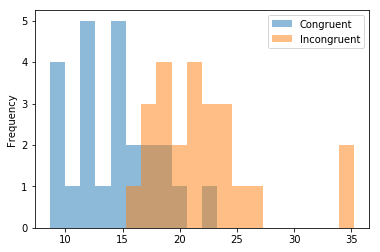

```python
%matplotlib inline
data.plot(kind='hist', bins = 20, alpha=0.5)
```

We notice here that both datasets (Congruent/Incongruent) seem to have a normal distribution.

To be noted, our Incongruent data seem to have some extreme data points (around 35)

We can see that Incongruent data are centered on a much higher mean value than Congruent data.

# 5. Now, perform the statistical test and report your results. What is your confidence level and your critical statistic value? Do you reject the null hypothesis or fail to reject it? Come to a conclusion in terms of the experiment task. Did the results match up with your expectations?

Two tailed t-test

Confidence level : 95%;

Number of subjects in the sample : 24

Degree of freedom(df) = n - 1 = 23

t statistics: 8.020706944109957 (8.0207)

t critical value: (-2.069, 2.069) (From T-table : https://s3.amazonaws.com/udacity-hosted-downloads/t-table.jpg)

t-statistic > t-critical

8.0207 > 2.069

```python
from math import *
import math
```

```python
n=len(data)
```

```python
#point estimate
PE = meanI - meanC
round(PE,2)
```

```
7.96
```

```python
# sample standard deviation of differences
#D = sample difference

data['Difference'] = data['Incongruent'] - data['Congruent']
```

```python
#DFM = difference from the mean

#SQD = squared differences from the mean

DFM = data['Difference'] - data['Difference'].mean()
data['SQD'] = DFM*DFM
```

```python
#SSD = sum of squared differences

SSD = data['SQD'].sum()
```

```python
# v = variance = SSD/(n-1)

v = SSD/(n-1)
```

```python
#s = sqrt(v)

std = sqrt(v)
round(std,2)
```

```
4.86
```

```python
# Calculate standard error

stdError = std / math.sqrt(24)
stdError
```

```
0.9930286347783406
```

```python
#t-statistic
#t = PE/(s/√n)
#PE = (μi - μc)

t = PE/stdError
round(t,4)
```

```
8.0207
```

```python
data
```

|  | Congruent | Incongruent | Difference | SQD |
| --- | --- | --- | --- | --- |
| 0 | 12.079 | 19.278 | 7.199 | 0.586437 |
| 1 | 16.791 | 18.741 | 1.950 | 36.177719 |
| 2 | 9.564 | 21.214 | 11.650 | 13.580760 |
| 3 | 8.630 | 15.687 | 7.057 | 0.824086 |
| 4 | 14.669 | 22.803 | 8.134 | 0.028631 |
| 5 | 12.238 | 20.878 | 8.640 | 0.455906 |
| 6 | 14.692 | 24.572 | 9.880 | 3.668023 |
| 7 | 8.987 | 17.394 | 8.407 | 0.195548 |
| 8 | 9.401 | 20.762 | 11.361 | 11.534231 |
| 9 | 14.480 | 26.282 | 11.802 | 14.724168 |
| 10 | 22.328 | 24.524 | 2.196 | 33.278957 |
| 11 | 15.298 | 18.644 | 3.346 | 21.333236 |
| 12 | 15.073 | 17.510 | 2.437 | 30.556481 |
| 13 | 16.929 | 20.330 | 3.401 | 20.828194 |
| 14 | 18.200 | 35.255 | 17.055 | 82.631888 |
| 15 | 12.130 | 22.158 | 10.028 | 4.256829 |
| 16 | 18.495 | 25.139 | 6.644 | 1.744491 |
| 17 | 10.639 | 20.429 | 9.790 | 3.331385 |
| 18 | 11.344 | 17.425 | 6.081 | 3.548671 |
| 19 | 12.369 | 34.288 | 21.919 | 194.719930 |
| 20 | 12.944 | 23.894 | 10.950 | 8.911469 |
| 21 | 14.233 | 17.960 | 3.727 | 17.958878 |
| 22 | 19.710 | 22.058 | 2.348 | 31.548349 |
| 23 | 16.004 | 21.157 | 5.153 | 7.906172 |